# Assignment3-Rishi-imdb

Ayush Rishi

2024-04-09

```r
knitr::opts_chunk$set(warning = FALSE , echo = TRUE , message = FALSE)
```

## Dataset Introductuion

- **Title** - IMDB Dataset (Top 2000 movies)
- **Link** - “https://www.kaggle.com/datasets/prishasawhney/imdb-dataset-top-2000-movies/data”
- **Data Summary** - The science of training machines to learn and produce models for future predictions is widely used. Here, IMDB_Rating column is our outcome which contains the information for rating of movies and we will predict the same using other predictors such as Movie_Name, Release_Year, Duration, Metascore, Votes, Genre, Director, Cast and Gross

## Kaggle Screenshot for No R code

Below is the screenshot from Kaggle which tells us that there are no R code available for this Dataset

[figure not shown]

## Important Libraries

```r
library(h2o)
library(dplyr)
library(tidyverse)
library(caret)
library(skimr)
library(recipes)
library(kableExtra)
library(DALEXtra)
```

## Initialize H2O Model

```r
h2o.init(nthreads = -1)
```

```
##
## H2O is not running yet, starting it now...
##
## Note:  In case of errors look at the following log files:
##     C:\R\RtmpkdXdCz\file60107c427e04/h2o_AyushRishi_started_from_r.out
##     C:\R\RtmpkdXdCz\file6010671e60d9/h2o_AyushRishi_started_from_r.err
##
##
## Starting H2O JVM and connecting:  Connection successful!
##
## R is connected to the H2O cluster:
##     H2O cluster uptime:         5 seconds 105 milliseconds
##     H2O cluster timezone:       America/New_York
##     H2O data parsing timezone:  UTC
##     H2O cluster version:        3.44.0.3
##     H2O cluster version age:    3 months and 19 days
##     H2O cluster name:           H2O_started_from_R_AyushRishi_gxg929
##     H2O cluster total nodes:    1
##     H2O cluster total memory:   3.95 GB
##     H2O cluster total cores:    8
##     H2O cluster allowed cores:  8
##     H2O cluster healthy:        TRUE
##     H2O Connection ip:          localhost
##     H2O Connection port:        54321
##     H2O Connection proxy:       NA
##     H2O Internal Security:      FALSE
##     R Version:                  R version 4.3.3 (2024-02-29 ucrt)
```

### Read the processed data

```r
yield_data_df = read_csv("Assignment3-Rishi-imdb.csv")
kable(head(yield_data_df,10)) |> kable_styling(bootstrap_options = c("hover"))
```

| Movie_Name | Release_Year | Duration | Metascore | Votes | Genre | Director | Cast | Gross | IMDB_Rating |
| --- | --- | --- | --- | --- | --- | --- | --- | --- | --- |
| The Godfather | 1972 | 175 | 100 | 2002655 | Crime, Drama | Francis Ford Coppola | Marlon Brando | 134.97 | 9.2 |
| The Godfather Part II | 1974 | 202 | 90 | 1358608 | Crime, Drama | Francis Ford Coppola | Al Pacino | 57.30 | 9.0 |
| Ordinary People | 1980 | 124 | 86 | 56476 | Drama | Robert Redford | Donald Sutherland | 54.80 | 7.7 |
| Lawrence of Arabia | 1962 | 218 | 100 | 313044 | Adventure, Biography, Drama | David Lean | Peter O’Toole | 44.82 | 8.3 |
| Straw Dogs | 1971 | 113 | 73 | 64331 | Crime, Drama, Thriller | Sam Peckinpah | Dustin Hoffman | 44.82 | 7.4 |
| Close Encounters of the Third Kind | 1977 | 138 | 90 | 216050 | Drama, Sci-Fi | Steven Spielberg | Richard Dreyfuss | 132.09 | 7.6 |
| Once Upon a Time in the West | 1968 | 166 | 82 | 348110 | Western | Sergio Leone | Henry Fonda | 5.32 | 8.5 |
| The Dirty Dozen | 1967 | 150 | 73 | 78858 | Action, Adventure, War | Robert Aldrich | Lee Marvin | 45.30 | 7.7 |
| Rosemary’s Baby | 1968 | 137 | 96 | 234034 | Drama, Horror | Roman Polanski | Mia Farrow | 44.82 | 8.0 |
| Cabaret | 1972 | 124 | 80 | 59119 | Drama, Music, Musical | Bob Fosse | Liza Minnelli | 42.77 | 7.8 |

#### Description about dataset

## *Predictors* :-

```
 - Movie_Name - This column shows the name of each movie.
 - Release_Year - This column represents the year in which the moviw was released.
 - Duration - This column indicates the length in .
 - Metascore - This column represents the score received on a scale of 1-100.
 - Votes - This column represents the total number of votes given to a specified movie.
 - Genre - This represents all the genres covered by the specified movie.
 - Director - This column specifies the director of a specific movie.
 - Cast - This column specifies the cast in the specified movie.
 - Gross - This column signifies the gross earnings a movie made in a scale of million dollars
```

## **Outcome** :-

```
 - IMDB_Rating - This column represents the average Rating a specified movie got over time.
```

## Split the Independent and dependent variable

Predictors in x_train_tbl

```r
x_train_tbl <- yield_data_df |> select(-"IMDB_Rating")
kable(head(x_train_tbl,10)) |> kable_styling(bootstrap_options = c("hover"))
```

| Movie_Name | Release_Year | Duration | Metascore | Votes | Genre | Director | Cast | Gross |
| --- | --- | --- | --- | --- | --- | --- | --- | --- |
| The Godfather | 1972 | 175 | 100 | 2002655 | Crime, Drama | Francis Ford Coppola | Marlon Brando | 134.97 |
| The Godfather Part II | 1974 | 202 | 90 | 1358608 | Crime, Drama | Francis Ford Coppola | Al Pacino | 57.30 |
| Ordinary People | 1980 | 124 | 86 | 56476 | Drama | Robert Redford | Donald Sutherland | 54.80 |
| Lawrence of Arabia | 1962 | 218 | 100 | 313044 | Adventure, Biography, Drama | David Lean | Peter O’Toole | 44.82 |
| Straw Dogs | 1971 | 113 | 73 | 64331 | Crime, Drama, Thriller | Sam Peckinpah | Dustin Hoffman | 44.82 |
| Close Encounters of the Third Kind | 1977 | 138 | 90 | 216050 | Drama, Sci-Fi | Steven Spielberg | Richard Dreyfuss | 132.09 |
| Once Upon a Time in the West | 1968 | 166 | 82 | 348110 | Western | Sergio Leone | Henry Fonda | 5.32 |
| The Dirty Dozen | 1967 | 150 | 73 | 78858 | Action, Adventure, War | Robert Aldrich | Lee Marvin | 45.30 |
| Rosemary’s Baby | 1968 | 137 | 96 | 234034 | Drama, Horror | Roman Polanski | Mia Farrow | 44.82 |
| Cabaret | 1972 | 124 | 80 | 59119 | Drama, Music, Musical | Bob Fosse | Liza Minnelli | 42.77 |

Outcome in y_train_tbl

```r
y_train_tbl <- yield_data_df |> select("IMDB_Rating")
kable(head(y_train_tbl,10) , align = 'l') |> kable_styling(bootstrap_options = c("hover"))
```

| IMDB_Rating |
| --- |
| 9.2 |
| 9.0 |
| 7.7 |
| 8.3 |
| 7.4 |
| 7.6 |
| 8.5 |
| 7.7 |
| 8.0 |
| 7.8 |

### Loading the H2O model previously saved and providing the predictive performance of the model.

```r
saved_model <- h2o.loadModel("Assignment3-Rishi-imdb.h2o")
```

## Predictive Performance

```r
summary(saved_model)
```

```
## Model Details:
## ==============
##
## H2ORegressionModel: deeplearning
## Model Key:  Assignment3-Rishi-imdb.h2o
## Status of Neuron Layers: predicting IMDB_Rating, regression, gaussian distribution, Quadratic loss, 556,929 weights/biases, 6.5 MB, 35,880 training samples, mini-batch size 1
##   layer units      type dropout       l1       l2 mean_rate rate_rms momentum
## 1     1  4091     Input  0.00 %       NA       NA        NA       NA       NA
## 2     2   128 Rectifier  0.00 % 0.000000 0.000000  0.354648 0.459392 0.000000
## 3     3   128 Rectifier  0.00 % 0.000000 0.000000  0.047087 0.047573 0.000000
## 4     4   128 Rectifier  0.00 % 0.000000 0.000000  0.127585 0.193372 0.000000
## 5     5     1    Linear      NA 0.000000 0.000000  0.002020 0.001536 0.000000
##   mean_weight weight_rms mean_bias bias_rms
## 1          NA         NA        NA       NA
## 2    0.000179   0.024058  0.195097 0.253445
## 3   -0.027691   0.096790  0.914984 0.032103
## 4   -0.014083   0.096252  0.803676 0.119963
## 5   -0.022881   0.063160 -0.053134 0.000000
##
## H2ORegressionMetrics: deeplearning
## ** Reported on training data. **
## ** Metrics reported on full training frame **
##
## MSE:  0.02201548
## RMSE:  0.1483762
## MAE:  0.1110946
## RMSLE:  0.02612343
## Mean Residual Deviance :  0.02201548
##
##
## H2ORegressionMetrics: deeplearning
## ** Reported on validation data. **
## ** Metrics reported on full validation frame **
##
## MSE:  0.1945323
## RMSE:  0.4410582
## MAE:  0.3342117
## RMSLE:  0.06088714
## Mean Residual Deviance :  0.1945323
##
```

[output cut: 28 more lines]

```
## ---
##                          variable relative_importance scaled_importance
## 4086 Director.Richard LaGravenese            0.172398          0.172398
## 4087              Cast.Chris Pine            0.172108          0.172108
## 4088       Movie_Name.missing(NA)            0.000000          0.000000
## 4089             Cast.missing(NA)            0.000000          0.000000
## 4090         Director.missing(NA)            0.000000          0.000000
## 4091            Genre.missing(NA)            0.000000          0.000000
##      percentage
## 4086   0.000196
## 4087   0.000196
## 4088   0.000000
## 4089   0.000000
## 4090   0.000000
## 4091   0.000000
```

## Explaination of Predictive Performance

# Conclusion of Predictive Performance:

Based on the metrics, the model appears to be accurate, especially considering the relatively low values of RMSE, MAE, and RMSLE on both the training and validation datasets.

### XAI (Expalinable AI)

```r
h2o_exp = explain_h2o(
saved_model, data = x_train_tbl,
y = y_train_tbl$IMDB.Rating == 1,
label = "H2O", type = "regression")
```

### Create a new observation

```r
x_test_data <- data.frame(
  Movie_Name = "Rocky",
  Release_Year = 1976,
  Duration = 120,
  Metascore = 70,
  Votes = 625924,
  Genre = "Drama, Sport",
  Director = "John G. Avildsen",
  Cast = "Sylvester Stallone",
  Gross = 117.24
)

new_observation_tbl_skim = partition(skim(x_test_data))
names(new_observation_tbl_skim)
```

```
## [1] "character" "numeric"
```

```r
string_2_factor_names_new_observation <- new_observation_tbl_skim$character$skim_variable
rec_obj_new_observation <- recipe(~ ., data = x_test_data) |>
  step_string2factor(all_of(string_2_factor_names_new_observation)) |>
  step_impute_median(all_numeric()) |> # missing values in numeric columns
  step_impute_mode(all_nominal()) |> # missing values in factor columns
  prep()
new_observation_processed_tbl <- bake(rec_obj_new_observation, x_test_data)
new_application = new_observation_processed_tbl
```

### XAI - Partial-dependence Profiles

```r
h2o_exp_pdp <- model_profile(
explainer = h2o_exp, variables = "Metascore")
```

## Plot display for Partial dependence profiles

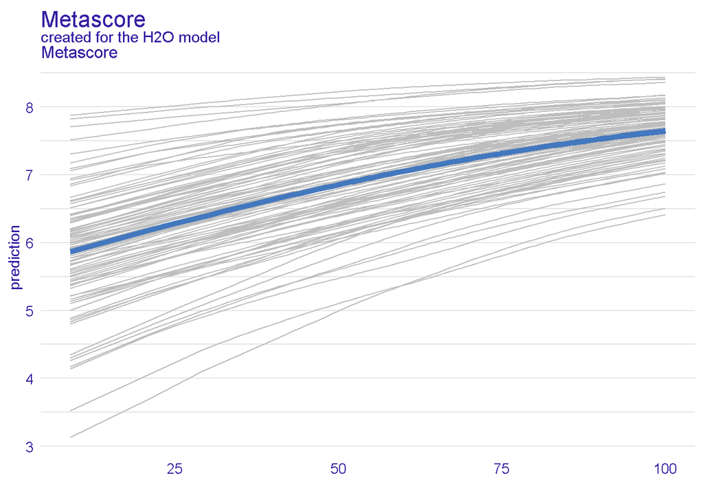

```r
plot(h2o_exp_pdp, geom="profiles") +
ggtitle("Metascore")
```

### Explaination of Partial-dependence Profiles

- Partial dependence plots (PDP) are a valuable tool in understanding the relationship between a feature and the predictions made by a machine learning model. Here, we are using the h2o package to generate partial dependence profiles for the variable “Metascore” in our model.

### XAI - SHAP

```r
h2o_exp_shap <- predict_parts(
explainer = h2o_exp, new_observation = new_application,
type = "shap", B = 5)
```

## Plot display for SHAP

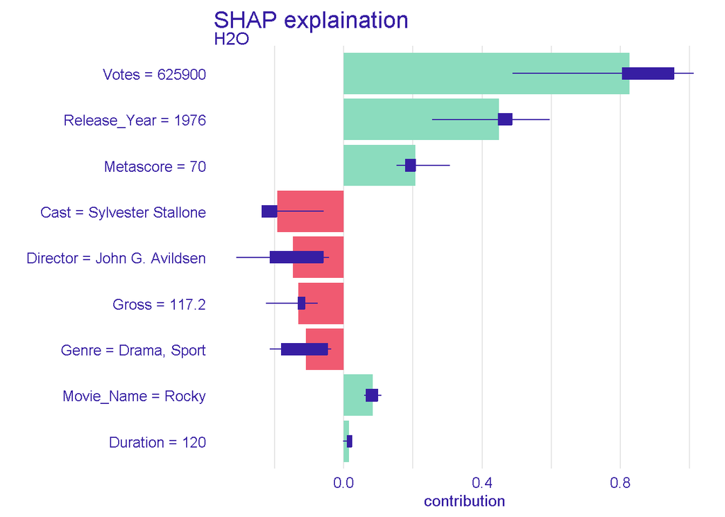

```r
plot(h2o_exp_shap) + ggtitle("SHAP explaination")
```

### Explaination of SHAP

- SHAP (SHapley Additive exPlanations) plots provide a visual representation of how individual features contribute to the prediction of a machine learning model. In this case, the values are provided in different percentiles (min, q1, median, mean, q3, max) of the SHAP distribution.

## Summary

**Votes = 625924 -** It has “Positive Impact” on the model’s output on higher percentiles indicating that it contributes more on model’s output.

**Release_Year = 1976 -** It has “Positive Impact” on the model’s output.

**Duration = 120 -** It has “Positive Impact” on the model’s output.

**Metascore = 70 -** It has “Positive Impact” on the model’s output.

**Movie_Name = Rocky -** It has “Positive Impact” on the model’s output.

**Genre = Drama, Sport -** It has “Negative Impact” on the model’s output.

**Director = John G. Avildsen -** It has “Negative Impact” on the model’s output.

**Cast = Sylvester Stallone -** It has “Negative Impact” on the model’s output.

**Gross = 117.24 -** It has “Negative Impact” on the model’s output.

SHAP values offer valuable insights into the contribution of each feature to the model’s predictions, providing a deeper understanding of the decision-making process employed by the model.

## Shut down h20

```r
h2o.shutdown(prompt = F)
```